# SML_assignment_1

Name: Ankur Ankan (s4753828)

## Exercise 1.1

```python
import numpy as np

# Defining the function f(x) = 1 + sin(6(x-2))
def f(x):
    """
    Returns the value of the function at x.

    Parameters
    ----------
    x: int, float or numpy.ndarray
       The values of x for which we want to find the value of f(x).

    Returns
    -------
    float or numpy.ndarray: If x was float or int, returns a float otherwise numpy.ndarray.
    """
    return (1 + np.sin(6*(x-2)))

# Generating 10 data points
x = np.linspace(0, 1, 10)
train_data = f(x)

# Generating Gaussian noise with mean at 0 and standard deviation of 0.3
noise = np.random.normal(loc=0, scale=0.3, size=10)

# Adding noise to generated data
noisy_train = train_data + noise

# Creating an array of the form [[x_1, y_1], [x_2, y_2], ..]
D_10 = np.stack((x, noisy_train), axis=1)

# Generating test data set
x = np.linspace(0, 1, 100)
test_data = f(x)
noise = np.random.normal(loc=0, scale=0.3, size=100)
noisy_test = test_data + noise
D_test = np.stack((x, noisy_test), axis=1)
```

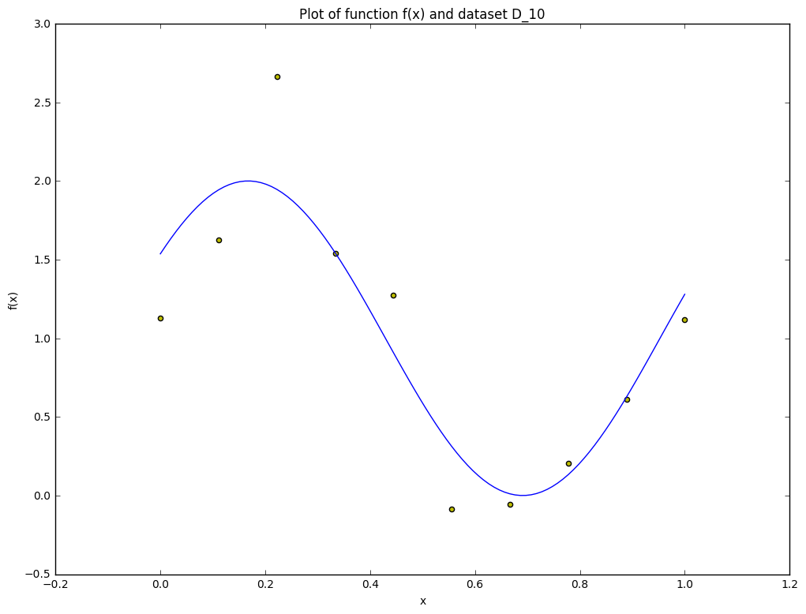

```python
# Plotting the function and generated data points
import matplotlib.pyplot as plt
%matplotlib inline
plt.figure(figsize=(12, 9))

fig = plt.gcf()
ax = plt.gca()

# Plotting the function
x = np.linspace(0, 1, 100)
y = f(x)
ax.plot(x, y)

# Plotting the dataset D_10
ax.scatter(D_10[:, 0], D_10[:, 1], c='y')
ax.set_xlabel('x')
ax.set_ylabel('f(x)')
plt.title("Plot of function f(x) and dataset D_10")
plt.show()
```

The above code generates two datasets `D_10` and `D_test`. `D_10` is a 10x2 array and `D_test` is a 100x2 array. The code generates data points from the function $ f(x) = 1 + sin(6(x-2)) $ using 10 and 100 inputs spaced uniformly in range[0, 1] for `D_10` and `D_test` respectively. In the graph above the blue line shows the original function $ f(x) = 1 + sin(6(x-2)) $ and the yellow points show the data points in `D_10`.

## Exercise 1.2

```python
from numpy.linalg import inv

def PolCurFit(D, M):
    """
    Fits the dataset D on a polynomial of order M.

    Parameters
    ----------
    D: 2-D array
       array containing the dataset on which to fit the polynomial. Should be of the form
       of [[x1, t1], [x2, t2], ...]

    M: int
       The order of the polynomial to fit to the dataset.

    Returns
    -------
    numpy.ndarray: Returns an array of values of the weight vector. The polynomial function
                   can be formed using the weights as: w[0] + w[1] * x + w[2] * x**2 ..
    """
    # Converting the dataset to a numpy array
    D = np.array(D)

    # Getting all the x values.
    x = D[:, 0]

    # Getting all the t values
    t = D[:, 1]

    # Creating empty arrays A and T
    A = np.empty((M+1, M+1))
    T = np.empty(M+1)

    # Computing the values of matrix A and vector T.
    for i in range(M+1):
        for j in range(M+1):
            A[i][j] = sum(x ** (i+j))
        T[i] = sum(t * x**i)

    w = np.dot(inv(A), T)
    return w
```

The sum-of-squares error function is given by:

$$ E(w) = \frac{1}{2} \sum_{n=1}^{N} \{y(x_n ; \mathbf{w}) - t_n \}^2 $$

To find it's minima we can solve it for $ \nabla E(w) = 0 $:

$$ \frac{\partial E(w)}{\partial w_i} = \sum_{n=1}^{N} (\sum_{j=1}^{M} x^j w^j - t_n) x^i $$$$ \frac{\partial E(w)}{\partial w_i} = \sum_{n=1}^{N} \sum_{j=0}^{M} w_j x^{i+j} - \sum_{n=1}^{N} t_n x^i $$$$ \frac{\partial E(w)}{\partial w_i} = \sum_{j=0}^{M} A_{ij} w_j - T_i$$

where $ A_{ij} = \sum_{n=1}^{N} x_n^{i+j} $ and $ T_i = \sum_{n=1}^{N} t_n x^i $.

Equating $ \frac{\partial E(w)}{\partial w_i} $ to $ 0 $ to find the minima, the above equation can be written in matrix form as: $$ \mathbf{Aw} = \mathbf{T} $$ where $ A $ is a MxM matrix, $ w $ and $ T $ are Mx1 martices.

$$ \mathbf{A^{-1} A w} = \mathbf{A^{-1}T} $$$$ \mathbf{w} = \mathbf{A^{-1}T} $$

The function `PolyCurFit` uses this final equation to find the value of $ \mathbf{w} $ and returns an array of size M+1 representing $ [w_0, w_1, w_2, ..., w_M] $.

## Exercise 1.3

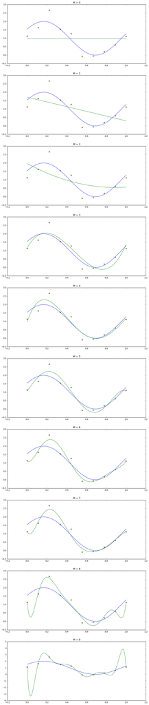

```python
%matplotlib inline

plt.figure(figsize=(12, 60))

for i in range(1, 11):
    plt.subplot(10, 1, i)

    # Plotting the function and the dataset D_10
    x = np.linspace(0, 1, 100)
    y = f(x)
    plt.plot(x, y)
    plt.scatter(np.linspace(0, 1, 10), noisy_train, c='y')

    # Plotting the predicted curve for M=i-1
    w = PolCurFit(D=D_10, M=i-1)
    predicted_y = np.zeros(100)
    for j in range(i):
        predicted_y += w[j] * (x**j)
    plt.plot(x, predicted_y)
    plt.title("M = {i}".format(i=i-1))
```

The above code fits the generated dataset `D_10` to polynomials of order $ M = [0, ... ,9] $. The generated graphs show the original function `f(x)` from which data points (shown in yellow points) were generated after adding noise. The green curve shows the predicted function using sum-of-squares error function.

We can see that as we increase the order of the polynomial, the fit to the data points get better. And for $ M=9 $ the predicted curve passes through all the data points. As we are increasing the value of $ M $ we are increasing the complexity of the model because of which it's fitting well to the training data. But such models will not be able to generalize and thus are prone to overfitting as we can clearly see in case of $ M = 8 $ or $ 9 $.

```python
def rms_error(t, t_pred):
    """
    Computes the RMS error.

    Parameters
    ----------
    t: numpy.ndarray
       The actual output values of the dataset.

    t_pred: numpy.ndarray
       The predicted values of the dataset from the fitted curve.

    Returns
    -------
    float: The RMS error.
    """
    E_w = 0.5 * (np.sum((t_pred - t)**2))
    return np.sqrt(2 * E_w / len(t))

def predict(w, x):
    """
    Predicts the values of x given the weights w.

    Parameters
    ----------
    w: numpy.ndarray
       The weights of the polynomial. Should be of the form w[0] + w[1] * x + w[2] * x**2 ..

    x: numpy.ndarray
       The values of x for which the predicted value needs to be computed.
    """
    y_pred = np.zeros(len(x))
    for i in range(len(w)):
        y_pred += w[i] * (x**i)
    return (y_pred)

# Array for storing test and training errors
error_array = np.empty((10, 2))
M = range(10)
for i in M:
    #Computing w
    w = PolCurFit(D_10, i)

    # Computing the predicted values for training and test datasets.
    y_pred_train = predict(w, D_10[:, 0])
    y_pred_test = predict(w, D_test[:, 0])

    # Computing the error for training and test dataset.
    train_error = rms_error(D_10[:, 1], y_pred_train)
    test_error = rms_error(D_test[:, 1], y_pred_test)

    # Storing the error values in error_array
    error_array[i][0] = train_error
    error_array[i][1] = test_error

    print("For M = {j}, RMS error for training set is {train_error} and for test is {test_error}".format(
        j=i, train_error=train_error, test_error=test_error))
```

```
For M = 0, RMS error for training set is 0.81505052674077 and for test is 0.7462808612899223
For M = 1, RMS error for training set is 0.6813428254114446 and for test is 0.5432267007550147
For M = 2, RMS error for training set is 0.6618866748172441 and for test is 0.49107894249060025
For M = 3, RMS error for training set is 0.3438458295398355 and for test is 0.3536208500990056
For M = 4, RMS error for training set is 0.2885194212567924 and for test is 0.32263602627824334
For M = 5, RMS error for training set is 0.2409771858382811 and for test is 0.3530116863183637
For M = 6, RMS error for training set is 0.205504767879342 and for test is 0.38535968315537505
For M = 7, RMS error for training set is 0.2019492395286351 and for test is 0.4006597265078535
For M = 8, RMS error for training set is 0.16797018072989298 and for test is 0.5417791144161865
For M = 9, RMS error for training set is 0.0005568706612059084 and for test is 1.4109439881842971
```

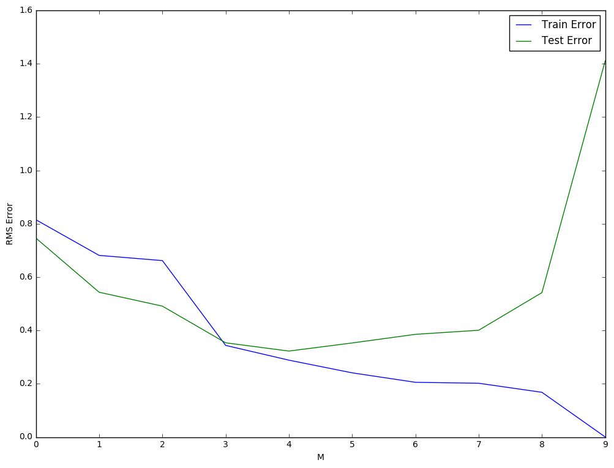

```python
plt.figure(figsize=(12, 9))

train_error = plt.plot(range(10), error_array[:, 0], label="Train Error")
test_error = plt.plot(range(10), error_array[:, 1], label="Test Error")
plt.xlabel('M')
plt.ylabel('RMS Error')
plt.legend()
plt.show()
```

The code above fits a curve over the training dataset `D_10` for different values of $ M $ and then computes the root mean square error over the training data and the test data. The graph shows the change in RMS error when $ M $ is varied. The blue line shows the error on training data set and green line on test data set. We can see from the graph that both the training and test errors are high for small values of $ M $. For a small value of $ M $ the model is too constrained to fit properly to the data and is therefore underfitting the data set leading to high RMS error. As we increase $ M $ both the train and test error decrease and get almost stable for $ M = 4 $ to $ 7 $. After $ M = 7 $ the training error keeps on decreasing but the test error starts increasing. Since the model is getting more and more complex it is better able to fit the training data points but is unable to generalize. And therefore the training error decreases but increases for the test dataset even when it has been generated through the same method. This is the case of overfitting. Hence the values of $ M $ with the minimum test error are expected to be the best generalized fit to our dataset.

## Exercise 1.4

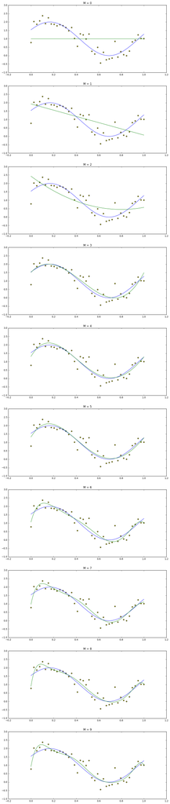

```python
# Creating the dataset D_40
x = np.linspace(0, 1, 40)
t = f(x)
noise = np.random.normal(loc=0, scale=0.3, size=40)
D_40 = np.stack((x, t + noise), axis=1)

# Plotting for different values of M
%matplotlib inline

plt.figure(figsize=(12, 60))

for i in range(1, 11):
    plt.subplot(10, 1, i)

    # Plotting the function and the dataset D_10
    x = np.linspace(0, 1, 100)
    y = f(x)
    plt.plot(x, y)
    plt.scatter(D_40[:, 0], D_40[:, 1], c='y')

    # Plotting the predicted curve for M=i-1
    w = PolCurFit(D=D_40, M=i-1)
    predicted_y = np.zeros(100)
    for j in range(i):
        predicted_y += w[j] * (x**j)
    plt.plot(x, predicted_y)
    plt.title("M = {i}".format(i=i-1))
```

```python
# Array for storing test and training errors
error_array = np.empty((10, 2))
M = range(10)
for i in M:
    #Computing w
    w = PolCurFit(D_40, i)

    # Computing the predicted values for training and test datasets.
    y_pred_train = predict(w, D_40[:, 0])
    y_pred_test = predict(w, D_test[:, 0])

    # Computing the error for training and test dataset.
    train_error = rms_error(D_40[:, 1], y_pred_train)
    test_error = rms_error(D_test[:, 1], y_pred_test)

    # Storing the error values in error_array
    error_array[i][0] = train_error
    error_array[i][1] = test_error

    print("For w = {j}, RMS error for training set is {train_error} and for test is {test_error}".format(
        j=i, train_error=train_error, test_error=test_error))
```

```
For w = 0, RMS error for training set is 0.7927561932048269 and for test is 0.7462900546403893
For w = 1, RMS error for training set is 0.5723098017385898 and for test is 0.5309365703306178
For w = 2, RMS error for training set is 0.5187389880781682 and for test is 0.4613611032569731
For w = 3, RMS error for training set is 0.3280741806591008 and for test is 0.30917756268991614
For w = 4, RMS error for training set is 0.31588751316113284 and for test is 0.29228206561571884
For w = 5, RMS error for training set is 0.31584664357810216 and for test is 0.29149519371771104
For w = 6, RMS error for training set is 0.2915094430399656 and for test is 0.324263317706707
For w = 7, RMS error for training set is 0.2876002828523833 and for test is 0.3221596785426304
For w = 8, RMS error for training set is 0.2838218323169382 and for test is 0.32384361929212785
For w = 9, RMS error for training set is 0.2828931184317065 and for test is 0.32433519526557336
```

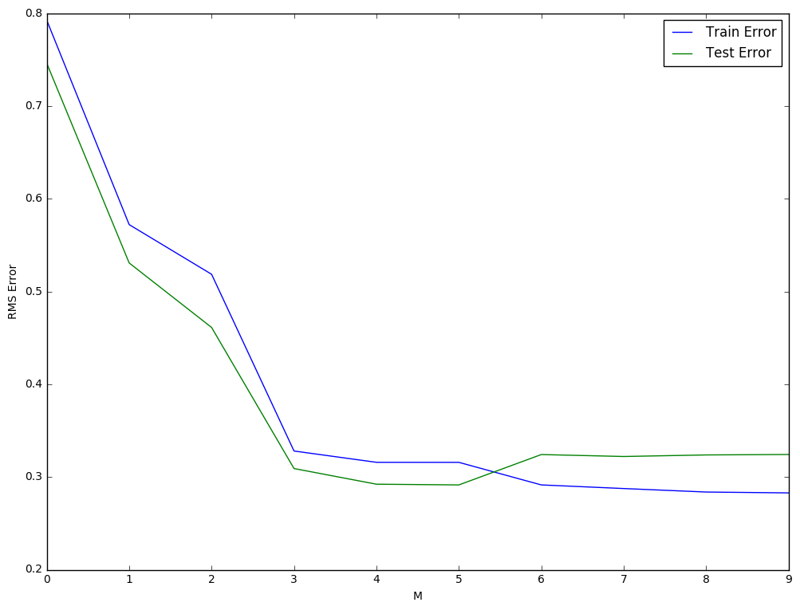

```python
plt.figure(figsize=(12, 9))

train_error = plt.plot(range(10), error_array[:, 0], label="Train Error")
test_error = plt.plot(range(10), error_array[:, 1], label="Test Error")
plt.xlabel('M')
plt.ylabel('RMS Error')
plt.legend()
plt.show()
```

In this case we have repeated the previous Exercise but on a bigger training data set. In the above graph we can see that for small values of $ M $ the curve is similar to the previous case and both training and test error decrease. But for higher values of $ M $ the test error doesn't increase as fast as it did in the previous case. This is because we are training on a bigger dataset and even for more complex models it's more difficult to overfit compared a smaller training dataset.

## Exercise 1.5

Our new error term is:

$$ \widetilde{E} = \frac{1}{2} \sum_{n=1}^{N} \{y(x_n ; \mathbf{w}) - t_n \}^2 + \frac{\lambda}{2} \sum_{j=0}^{M} w_j^2 $$

To find it's minima we can solve it for $ \nabla E(w) = 0 $:

$$ \frac{\partial E(w)}{\partial w_i} = \sum_{n=1}^{N}( (\sum_{j=1}^{M} x^j w^j - t_n) x^i) + \lambda w_i $$$$ \frac{\partial E(w)}{\partial w_i} = \sum_{n=1}^{N} \sum_{j=0}^{M} w_j x^{i+j} - \sum_{n=1}^{N} t_n x^i + \lambda w_i $$$$ \frac{\partial E(w)}{\partial w_i} = \sum_{j=0}^{M} A_{ij} w_j - T_i + \lambda w_i$$

where $ A_{ij} = \sum_{n=1}^{N} x_n^{i+j} $ and $ T_i = \sum_{n=1}^{N} t_n x^i $.

Equating $ \frac{\partial E(w)}{\partial w_i} $ to $ 0 $ to find the minima, the above equation can be written in matrix form as: $$ \mathbf{Aw} + \lambda \mathbf{w} = \mathbf{T} $$ where $ A $ is a MxM matrix, $ w $ and $ T $ are Mx1 martices and \lambda is a scalar. This equation can also be written as:

$$ \mathbf{Aw} + \lambda \mathbf{I w} = \mathbf{T} $$

where I is an identity matrix of size MxM.

$$ (\mathbf{A} + \lambda \mathbf{I}) \mathbf{w} = \mathbf{T} $$$$ \mathbf{w} = (\mathbf{A} + \lambda \mathbf{I})^{-1} \mathbf{T} $$

The function `PolyCurFit` uses this final equation to find the value of $ \mathbf{w} $ and returns an array of size M+1 representing $ [w_0, w_1, w_2, ..., w_M] $.

```python
def PolCurFit(D, M, lam):
    """
    Fits the dataset D on a polynomial of order M.

    Parameters
    ----------
    D: 2-D array
       array containing the dataset on which to fit the polynomial. Should be of the form
       of [[x1, t1], [x2, t2], ...]

    M: int
       The order of the polynomial to fit to the dataset.

    lam: int, float
       The regularization term.

    Returns
    -------
    numpy.ndarray: Returns an array of values of the weight vector. The polynomial function
                   can be formed using the weights as: w[0] + w[1] * x + w[2] * x**2 ..
    """
    # Converting the dataset to a numpy array
    D = np.array(D)

    # Getting all the x values.
    x = D[:, 0]

    # Getting all the t values
    t = D[:, 1]

    # Creating empty arrays A and T
    A = np.empty((M+1, M+1))
    T = np.empty(M+1)
    I = np.identity(M+1)

    # Computing the values of matrix A and vector T.
    for i in range(M+1):
        for j in range(M+1):
            A[i][j] = sum(x ** (i+j))
        T[i] = sum(t * x**i)

    w = np.dot(inv(A + lam * I), T)
    return w
```

```python
for i in range(10):
    print("The coeficients for M={i} are: {coef}".format(i=i, coef=PolCurFit(D_10, i, lam=10)))
```

```
The coeficients for M=0 are: [ 0.50139679]
The coeficients for M=1 are: [ 0.47940039  0.0879856 ]
The coeficients for M=2 are: [ 0.47562026  0.08372428  0.02754263]
The coeficients for M=3 are: [ 0.47369825  0.08123545  0.02509971  0.02141271]
The coeficients for M=4 are: [ 0.47208907  0.07892999  0.02272651  0.01908165  0.02504771]
The coeficients for M=5 are: [ 0.47067115  0.07672868  0.0203738   0.01671272  0.02270657  0.02917368]
The coeficients for M=6 are: [ 0.46944649  0.07469472  0.01813168  0.01440814  0.02039424  0.02687609
  0.0320789 ]
The coeficients for M=7 are: [ 0.46840687  0.07286327  0.01605904  0.01224003  0.01819036  0.02466398
  0.02987191  0.03374233]
The coeficients for M=8 are: [ 0.46753228  0.07123875  0.01417806  0.01024218  0.01613639  0.02258399
  0.02778188  0.03165101  0.03445922]
The coeficients for M=9 are: [ 0.46679894  0.06980872  0.01248841  0.00842327  0.01424757  0.02065618
  0.02583244  0.02969014  0.03249309  0.03451787]
```

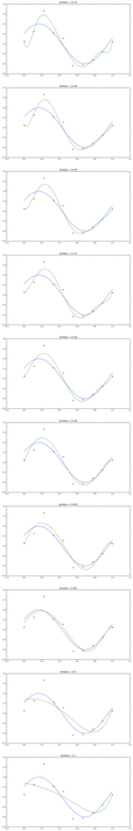

```python
fig = plt.figure(figsize=(12, 80))
lam = range(-10, 0)
for l in lam:
    plt.subplot(10, 1, l+11)
    w = PolCurFit(D_10, 9, 10**l)
    x = np.linspace(0, 1, 100)
    plt.plot(x, f(x))
    plt.scatter(D_10[:, 0], D_10[:, 1], c='y')
    plt.plot(x, predict(w, x))
    plt.title("lambda = {l}".format(l=10**l))
```

We can see in the above graph that when the value of $ \lambda $ is very small the predicted curve is overfitting the dataset. This case is similar to not having a regularization term and hence the predicted curve is almost passing through each of the training data points. As we increase the value of $ \lambda $ we get better fit to the data points but for higher values of $ \lambda $ we again get poor results because $ \lambda $ becomes more dominating in the error function.

```python
# Array for storing test and training errors
error_array = np.empty((14, 2))
i = 0

for ln_lam in range(-18, -4):
    #Computing w
    lam = 10 ** ln_lam
    w = PolCurFit(D_10, 9, ln_lam)

    # Computing the predicted values for training and test datasets.
    y_pred_train = predict(w, D_10[:, 0])
    y_pred_test = predict(w, D_test[:, 0])

    # Computing the error for training and test dataset.
    train_error = rms_error(D_10[:, 1], y_pred_train)
    test_error = rms_error(D_test[:, 1], y_pred_test)

    # Storing the error values in error_array
    error_array[i][0] = train_error
    error_array[i][1] = test_error
    i+=1

    print("For ln \lambda = {j}, RMS error for training set is {train_error} and for test is {test_error}".format(
        j=ln_lam, train_error=train_error, test_error=test_error))
```

```
For ln \lambda = -18, RMS error for training set is 5.8211387941130015 and for test is 5.305398897539357
For ln \lambda = -17, RMS error for training set is 3.973638463185192 and for test is 3.5982371354702805
For ln \lambda = -16, RMS error for training set is 3.008853219033877 and for test is 2.7083380908726093
For ln \lambda = -15, RMS error for training set is 2.4384132199144193 and for test is 2.184245368488086
For ln \lambda = -14, RMS error for training set is 2.080680147642259 and for test is 1.8580048583529583
For ln \lambda = -13, RMS error for training set is 1.8528572766533018 and for test is 1.6529070336448979
For ln \lambda = -12, RMS error for training set is 1.7125243502570522 and for test is 1.5294439011547087
For ln \lambda = -11, RMS error for training set is 1.6373137150380568 and for test is 1.46657214770381
For ln \lambda = -10, RMS error for training set is 1.6176539660433369 and for test is 1.455060362124805
For ln \lambda = -9, RMS error for training set is 1.6562964281639743 and for test is 1.4970578111634039
For ln \lambda = -8, RMS error for training set is 1.7764061533969953 and for test is 1.6134518015789767
For ln \lambda = -7, RMS error for training set is 2.056703091534441 and for test is 1.875811520953892
For ln \lambda = -6, RMS error for training set is 2.8251356108321035 and for test is 2.5824798347887215
For ln \lambda = -5, RMS error for training set is 7.764823054526219 and for test is 7.083515102359518
```

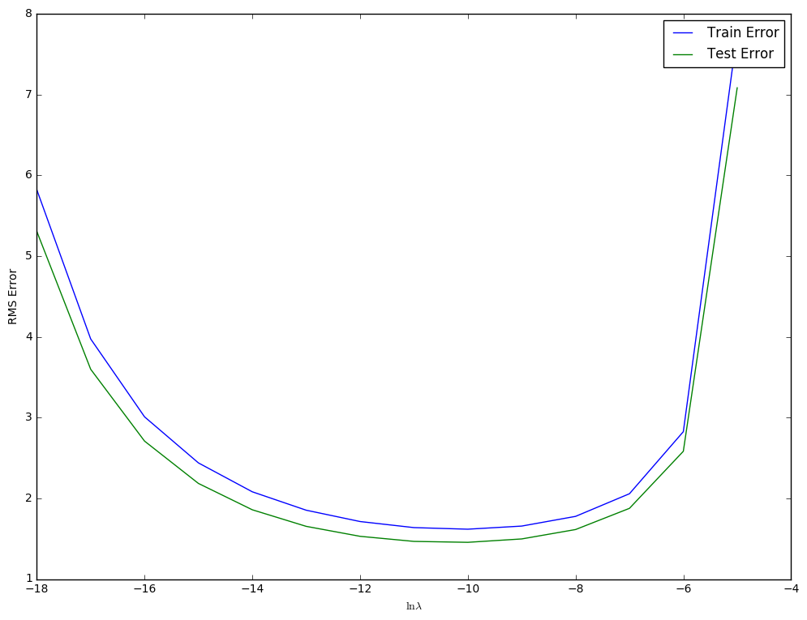

```python
plt.figure(figsize=(12, 9))

train_error = plt.plot(range(-18, -4), error_array[:, 0], label="Train Error")
test_error = plt.plot(range(-18, -4), error_array[:, 1], label="Test Error")
plt.xlabel('$ \ln \lambda $')
plt.ylabel('RMS Error')
plt.legend()
plt.show()
```

## Exercise 2.1

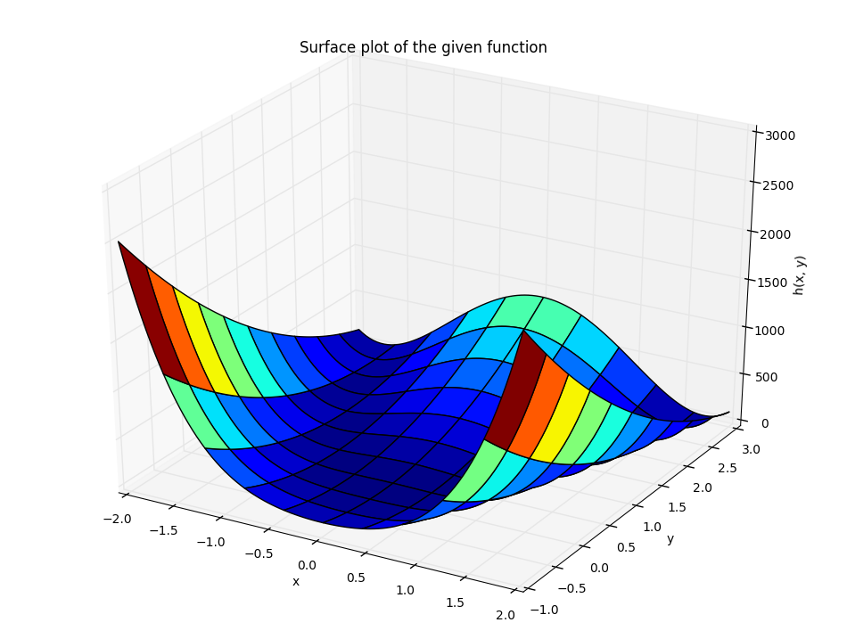

```python
import numpy as np
from mpl_toolkits.mplot3d import axes3d
import matplotlib.pyplot as plt
from matplotlib import cm
%matplotlib inline

fig = plt.figure(figsize=(12, 9))
ax = fig.add_subplot(111, projection='3d')
x, y = np.meshgrid(np.linspace(-2, 2, 100), np.linspace(-1, 3, 100))
z = 100 * ((y - x**2)**2) + (1 - x)**2
ax.plot_surface(x, y, z, cmap=cm.jet)
ax.set_xlabel("x")
ax.set_ylabel("y")
ax.set_zlabel("h(x, y)")
ax.set_title("Surface plot of the given function")
```

According to the plot the numerical minimization with gradient descent should be slow. We can see that the middle region in the plot is almost at the same level and therefore will have a very small gradient. And because of the small gradient we will be moving slowly towards the minima. We might choose a larger step size but that might lead to oscillations or overshooting the minima.

## Exercise 2.2

$$ h(x, y) = 100(y - x^2)^2 + (1-x)^2 $$

For finding the minima we will take the partial derivate of the function with respect to x and y and equate them to 0.

$$ \frac{\partial h (x, y)}{\partial x} = 100 (y-x^2) (-2x) + 2(1-x)(-1) $$$$ 0 = 200(-xy + x^3) + x - 1 $$

Computing partial derivate with respect to $ y $:

$$ \frac{\partial h (x, y)}{\partial y} = 200(y-x^2) $$$$ 0 = 200(y-x^2) $$$$ y = x^2 $$

Substituting this in the previous equation:

$$ 0 = 200(-x \cdot x^2 + x^3) + x - 1 $$$$ x=1 $$

Therefore: $$ y=1 $$

Since there are no other solutions to the equation, therefore (1, 1) is the unique minimum of the function.

## Exercise 2.3

$$ h(x, y) = 100 (y-x^2)^2 + (1-x)^2 $$

Computing the partial derivatives of $ h(x, y) $:

$$ \frac{\partial h(x, y)}{\partial x} = 400(x^3 - xy) + 2(x - 1) $$$$ \frac{\partial h(x, y)}{\partial y} = 200(y - x^2) $$

Using these partial derivatives we can now write the iteration rule of the gradient descent:

$$ x_{n+1} = x_n - \eta (400(-x_n y_n + x_n^3) + 2(x_n - 1)) $$$$ y_{n+1} = y_n - \eta (200(y_n - x_n^2)) $$

## Exercise 2.4

```python
def gradient_descent(initial=(0, 0), n=0.001, max_loops=10**9):
    steps = []
    x_old = initial[0]
    y_old = initial[1]
    x_new = 1000
    y_new = 1000
    loop_no = 0

    while loop_no < max_loops:
        try:
            x_new = x_old - n * (400 *(-x_old * y_old + x_old**3) + 2*(x_old - 1))
            y_new = y_old - n * (200 *(y_old - x_old**2))
        except OverflowError: # Case when values get too large
            return False, np.array(steps), loop_no
        steps.append([x_new, y_new])
        if np.allclose([x_new, y_new], [x_old, y_old]):
            break
        else:
            x_old = x_new
            y_old = y_new
        loop_no += 1
    return True, np.array(steps), loop_no
```

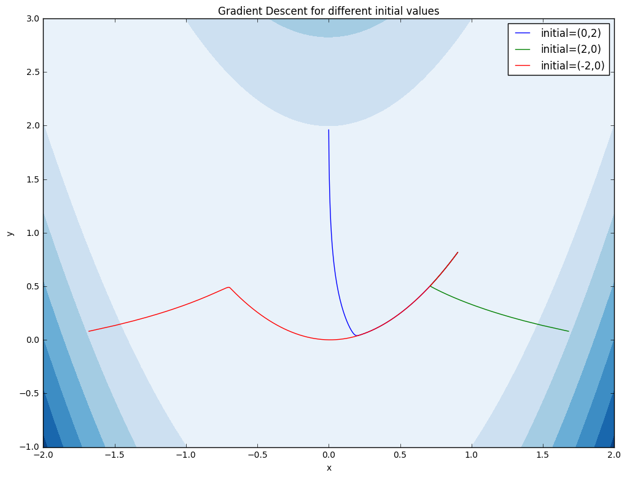

```python
from matplotlib import cm
fig = plt.figure(figsize=(12, 9))
ax = fig.gca()
x = np.linspace(-2, 2, 100)
y = np.linspace(-1, 3, 100)
xx, yy = np.meshgrid(x, y)
z = 100 * ((yy - xx**2)**2) + (1 - xx)**2
plt.contourf(xx, yy, z, cmap=cm.Blues)
plt.xlabel('x')
plt.ylabel('y')

# Trying for different initial values
steps = gradient_descent(initial=(0, 2), n=0.0001)[1]
plt.plot(steps[:, 0], steps[:, 1], label="initial=(0,2)")
steps = gradient_descent(initial=(2, 0), n=0.0001)[1]
plt.plot(steps[:, 0], steps[:, 1], label="initial=(2,0)")
steps = gradient_descent(initial=(-2, 0), n=0.0001)[1]
plt.plot(steps[:, 0], steps[:, 1], label="initial=(-2,0)")
plt.title("Gradient Descent for different initial values")
plt.legend()
```

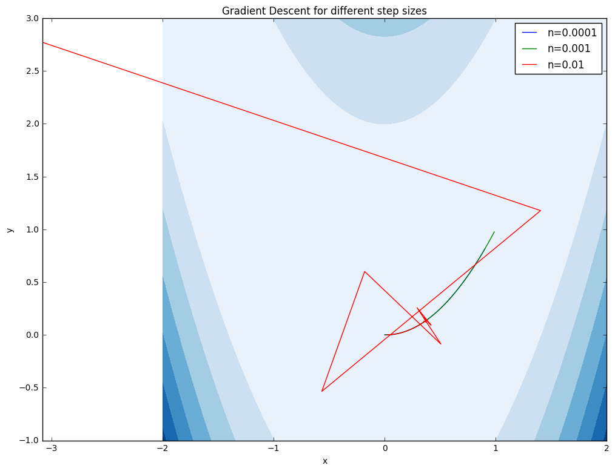

```python
from matplotlib import cm
fig = plt.figure(figsize=(12, 9))
ax = fig.gca()
x = np.linspace(-2, 2, 100)
y = np.linspace(-1, 3, 100)
xx, yy = np.meshgrid(x, y)
z = 100 * ((yy - xx**2)**2) + (1 - xx)**2
plt.contourf(xx, yy, z, cmap=cm.Blues)
plt.xlabel('x')
plt.ylabel('y')

# Trying for different values of n.
n = [0.0001, 0.001, 0.0005]
converge_0, steps_0, loops_0 = gradient_descent(initial=(0, 0), n=0.0001)
converge_1, steps_1, loops_1 = gradient_descent(initial=(0, 0), n=0.001)
converge_2, steps_2, loops_2 = gradient_descent(initial=(0, 0), n=0.01)

if converge_0:
    plt.plot(steps_0[:, 0], steps_0[:, 1], label="n=0.0001")
if converge_1:
    plt.plot(steps_1[:, 0], steps_1[:, 1], label="n=0.001")
if converge_2:
    plt.plot(steps_2[:, 0], steps_2[:, 1], label="n=0.01")

plt.plot(steps_2[:-5, 0], steps_2[:-5, 1], label="n=0.01")
plt.title("Gradient Descent for different step sizes")
plt.legend()
```

```python
print("For n=0.0001, converged in: {loops} loops".format(loops=loops_0))
print("For n=0.001, converged in: {loops} loops".format(loops=loops_1))
```

```
For n=0.0001, converged in: 32309 loops
For n=0.001, converged in: 8094 loops
```

We can see here that the gradient descent coverges for `n=0.0001` and `n=0.001` but doesn't converge for `n=0.01`. Increasing the value of `n` reduces the number of loops required for convergence. `n=0.0001` took 32309 loops where as `n=0.001` took just 8094 loops which is a around 4 times less than `n=0.0001`.

The convergence in this case is very slow as the algorithm is taking 8000 steps for moving from `(0, 0)` to `(1, 1)`. Examining the values of (x, y) at different steps of convergence:

```python
# Last 20 steps
steps_1[-20:]
```

```
array([[ 0.98779771,  0.97569513],
       [ 0.98780268,  0.97570497],
       [ 0.98780765,  0.97571481],
       [ 0.98781262,  0.97572464],
       [ 0.98781758,  0.97573446],
       [ 0.98782254,  0.97574428],
       [ 0.9878275 ,  0.9757541 ],
       [ 0.98783246,  0.97576391],
       [ 0.98783741,  0.97577372],
       [ 0.98784236,  0.97578353],
       [ 0.98784731,  0.97579333],
       [ 0.98785226,  0.97580313],
       [ 0.98785721,  0.97581292],
       [ 0.98786215,  0.97582271],
       [ 0.9878671 ,  0.97583249],
       [ 0.98787204,  0.97584228],
       [ 0.98787698,  0.97585205],
       [ 0.98788191,  0.97586183],
       [ 0.98788685,  0.9758716 ],
       [ 0.98789178,  0.97588136]])
```

The values of `x` and `y` are moving very slowly towards the minima. This is because of the small gradient of the curve around it's minima.

## Exercise 3.1

We need to compute $ P(F_1 = A \mid F_2 = G) $. Using product rule we can write:

$$ P(F_1 = A \mid F_2 = G) = \frac{P(F_1=A, F_2 = G)}{P(F_2=G)} $$$$ P(F_1 = A \mid F_2 = G) = \frac{P(B=1) \cdot P(F_1=A \mid B=1) \cdot P(F_2=G \mid B=1) + P(B=2) \cdot P(F_1=A \mid B=2) \cdot P(F_2=G \mid B=2)}{\sum_{F_1} P(B=1) \cdot P(F_1 \mid B=1) \cdot P(F_2=G \mid B=1) + P(B=2) \cdot P(F_1 \mid B=2) \cdot P(F_2=G \mid B=2)} $$$$ P(F_1 = A \mid F_2 = G) = \frac{13}{18} = 0.72 $$

Since we are picking the second item from the same box as the first item, the events $ F_1 $ and $ F_2 $ aren't independent. We can also verify this by checking that $ P(F_1 \mid F_2) \not= P(F_1) $.

Our initial probability of getting $ F_1 = A $ is: $$ P(F_1 = A) = \frac{1}{2} \cdot \frac{8}{12} + \frac{1}{2} \cdot \frac{15}{18} = 0.75 $$

In the question since we are given that $ F_2 = G $ and we know that $ P(F_2=G \mid B=1) > P(F_2=G \mid B=2) $, therefore knowing that $ F_2 = G $ increases our belief that box 1 was selected for $ F_1 $. And also $ P(F_1=A \mid B=1) < P(F_1=A \mid B=2) $ therefore the increase in our belief that box 1 was chosen decreases our belief of getting $ F_1 = A $.

## Exercise 3.2

$$ P(F_2 = G \mid F_1 = A) = \frac{P(F_2 = G , F_1 = A}{\sum_{F_2} P(F_1=A, F_2)} $$$$ P(F_2 = G \mid F_1 = A) = \frac{P(B=1) P(F_1=A \mid B=1) P(F_2 = G \mid B=1) + P(B=2) P(F_1=A \mid B=2) P(F_2 = G \mid B=2)}{\sum_{F_2} P(B=1) P(F_1=A \mid B=1) P(F_2 \mid B=1) + P(B=2) P(F_1=A \mid B=2) P(F_2 \mid B=2)} $$$$ P(F_2 = G \mid F_1 = A) = \frac{7}{72} \cdot \frac{72}{42} = \frac{1}{6} $$

Similarly we have, $$ P(F_2 = G \mid F_1 = G) = P(F_2 = G \mid F_1 = O) = \frac{1}{6} $$

Also, $$ P(F_2 = G) = P(F_2=G \mid B=1) P(B=1) + P(F_2=G \mid B=2) P(B=2) = \frac{1}{2} \cdot \frac{4}{24} + \frac{1}{2} \cdot \frac{3}{18} = \frac{1}{6} $$

So we can see here that $ P(F_2 = G \mid F_1) = P(F_2=G) $. But for showing that the variables $ F_1 $ and $ F_2 $ are independent the equation should be true for all possible values of $ F_2 $ and $ F_1 $.

$$ P(F_2 = A \mid F_1 = A) = \frac{P(F_1 = A, F_2 = A)}{\sum_{F_2} P(F_1=A, F_2)} = \frac{\frac{29}{72}}{\frac{29}{72} + \frac{7}{72} + \frac{6}{72}} = \frac{29}{42} $$

and

$$ P(F_2 = A) = P(F_2 = A \mid B=1) P(B=1) + P(F_2=A \mid B=2) P(B=2) = \frac{7}{12} $$

Here we see that $ P(F_2=A \mid F_1=A) \not= P(F_2=A) $. Hence the random variables $ F_1 $ and $ F_2 $ are not independent.

The reason that we are getting $ P(F_2=G \mid F_1) = P(F_2=G) $ is because $ P(F_2=G \mid B=1) = P(F_2=G \mid B=2) = \frac{1}{6} $. Therefore, observing the outcome of $ F_1 $ does change our belief in which box was selected but since the probability of getting a grapefruit from any of the boxes is same, the overall probability still remains the same.